# Alpine dry meadow fertilization results

CTW

2019-10-27

### Temporal trend in alpine dry meadow forb and grass relative abundance

As a double check, these are the replicated figures and tables I get following methods described in the manuscript draft. For the most part, numbers are very similar and may be slightly different due to old species codes being consolidated into the same USDA species code. I did find a number of typos in old species codes, which maybe could result in slight variation to diversity or richness numbers. The biggest difference in NutNet results here vs. what’s shown in the manuscript is in at least 2013 *Selaginella densa* was classed and surveyed as ground cover (non-vegetation hits). That is, I can replicate 2013 numbers in the current draft ms when I also class *S. densa* as ground cover. In other surveys, however, *S. densa* was not necessarily surveyed as ground cover (for example, it was recorded below grass at a given point, or a in few cases, other plants were recorded as hit below *S. densa* at the top). *S. densa* is a vascular plant, and is relatively abundant in some plots, so I treated it as plant cover across all years and sites in results presented here.

With that, here are the updated figures and tables I get using the cleaned datasets, along with some additional figure panels, tables, or figures using new data added to the time-series dataset (e.g. 2003 and 2005 saddle sffert data). The 2003 and 2005 saddle data are REU data (2003 = Colin Tucker, REU with Bill Bowman; 2005 = Jane Griffin Smith, REU with Tim Seastedt), so not sure if data quality (specifically plant ID) is sufficient enough to want to include in the ms analyses, but at minimum *Geum rossii* numbers align with the rest of the Saddle *Geum rossii* time-series data and I think would be interesting data points to include.

#### Saddle trends

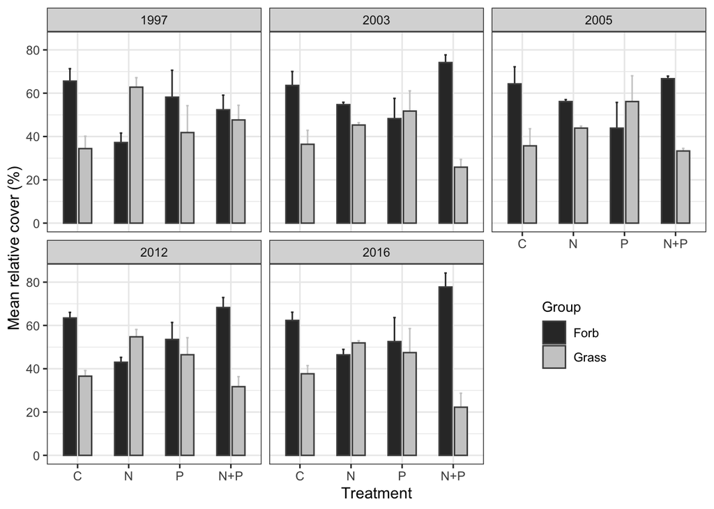

Fig 1. Mean relative forb and grass cover, Saddle, 1997-2016

| site | yr | fxnlgrp | C mean | C se | N mean | N se | N+P mean | N+P se | P mean | P se |
| --- | --- | --- | --- | --- | --- | --- | --- | --- | --- | --- |
| sdl | 1997 | Forb | 65.58 | 5.72 | 37.22 | 4.38 | 52.34 | 6.75 | 58.17 | 12.42 |
| sdl | 1997 | Grass | 34.42 | 5.72 | 62.78 | 4.38 | 47.66 | 6.75 | 41.83 | 12.42 |
| sdl | 2003 | Forb | 63.58 | 6.44 | 54.71 | 1.10 | 74.15 | 3.54 | 48.27 | 9.35 |
| sdl | 2003 | Grass | 36.42 | 6.44 | 45.29 | 1.10 | 25.85 | 3.54 | 51.73 | 9.35 |
| sdl | 2005 | Forb | 64.31 | 7.89 | 56.13 | 0.91 | 66.69 | 1.19 | 43.86 | 11.89 |
| sdl | 2005 | Grass | 35.69 | 7.89 | 43.87 | 0.91 | 33.31 | 1.19 | 56.14 | 11.89 |
| sdl | 2012 | Forb | 63.43 | 2.60 | 43.01 | 2.25 | 68.27 | 4.63 | 53.53 | 7.86 |
| sdl | 2012 | Grass | 36.57 | 2.60 | 54.74 | 3.41 | 31.73 | 4.63 | 46.47 | 7.86 |
| sdl | 2016 | Forb | 62.33 | 3.78 | 46.41 | 2.53 | 77.76 | 6.44 | 52.54 | 11.09 |
| sdl | 2016 | Grass | 37.67 | 3.78 | 51.92 | 1.00 | 22.24 | 6.44 | 47.46 | 11.09 |

You’ll notice standard errors are the same per treatment per year (e.g. 5.72 for both Forb and Grass in Control in 1997). I think this happens because Grass relative cover is 100-Forb relative cover, and so they will have a comparable amount of deviation (i.e. standard deviation is the same), and the sample size for both is 4.

I did throw everything in a global ANOVA just to see if there are any significant effects or interactions between treatment, functional group, and time. “Met” here is short for metric, but standard for functional group (forb or grass). Mean cover between forb and grass overall is statistically distinct, and there is an interaction between functional group and treatment, with a small statistically significant interaction between treatment, functional group, and time.

```
##              Df Sum Sq Mean Sq F value   Pr(>F)
## trt           3      5       2   0.009   0.9989
## met           1   9518    9518  54.298 1.23e-11 ***
## yr            1      2       2   0.010   0.9213
## trt:met       3  11133    3711  21.170 2.03e-11 ***
## trt:yr        3      5       2   0.010   0.9987
## met:yr        1    389     389   2.222   0.1383
## trt:met:yr    3   1489     496   2.832   0.0405 *
## Residuals   144  25242     175
## ---
## Signif. codes:  0 '***' 0.001 '**' 0.01 '*' 0.05 '.' 0.1 ' ' 1
```

By year, here are the ANOVA results. Functional group is significant in all years but 1997, treatment never is (because it would be the mean by treatment.. which always averages to 50).. and the interaction between functional group and treatment always is!

Table S2. ANOVA results for saddle, effects of treatment and functional group (forb or grass) on mean relative cover. Separate ANOVAs were run by year, n=4 per treatment, per functional group.

| site | yr | fxngrp_F.stat | fxngrp_p.value | trt_F.stat | trt_p.value | trt:fxngrp_F.stat | trt:fxngrp_p.value |
| --- | --- | --- | --- | --- | --- | --- | --- |
| sdl | 1997 | 1.4090 | 0.2468 | 0.0000 | 1.0000 | 4.6006 | 0.0111 |
| sdl | 2003 | 23.2474 | 0.0001 | 0.0000 | 1.0000 | 7.0828 | 0.0014 |
| sdl | 2005 | 9.3311 | 0.0054 | 0.0000 | 1.0000 | 4.1274 | 0.0171 |
| sdl | 2012 | 17.5465 | 0.0003 | 0.0258 | 0.9943 | 9.3805 | 0.0003 |
| sdl | 2016 | 17.4248 | 0.0003 | 0.0076 | 0.9991 | 7.8784 | 0.0008 |

Saddle: Tukey HSD, significant differences (p<=0.05), ANOVAs run separately for each year

| comparison | diff | lwr | upr | p.adj | term | yr |
| --- | --- | --- | --- | --- | --- | --- |
| Grass_rel-Forb_rel | -20.3568 | -29.0706 | -11.6429 | 0.0001 | met | 2003 |
| C:Grass_rel-N+P:Forb_rel | -37.7394 | -65.7054 | -9.7734 | 0.0034 | trt:met | 2003 |
| N:Grass_rel-N+P:Forb_rel | -28.8623 | -56.8283 | -0.8963 | 0.0397 | trt:met | 2003 |
| N+P:Grass_rel-C:Forb_rel | -37.7394 | -65.7054 | -9.7734 | 0.0034 | trt:met | 2003 |
| N+P:Grass_rel-N:Forb_rel | -28.8623 | -56.8283 | -0.8963 | 0.0397 | trt:met | 2003 |
| N+P:Grass_rel-N+P:Forb_rel | -48.3097 | -76.2757 | -20.3437 | 0.0002 | trt:met | 2003 |
| Grass_rel-Forb_rel | -15.4941 | -25.9628 | -5.0255 | 0.0054 | met | 2005 |
| Grass_rel-Forb_rel | -14.6808 | -21.9143 | -7.4474 | 0.0003 | met | 2012 |
| C:Grass_rel-C:Forb_rel | -26.8634 | -50.0782 | -3.6486 | 0.0155 | trt:met | 2012 |
| C:Grass_rel-N+P:Forb_rel | -31.7044 | -54.9193 | -8.4896 | 0.0030 | trt:met | 2012 |
| N+P:Forb_rel-N:Forb_rel | 25.2673 | 2.0525 | 48.4821 | 0.0262 | trt:met | 2012 |
| N+P:Grass_rel-C:Forb_rel | -31.7044 | -54.9193 | -8.4896 | 0.0030 | trt:met | 2012 |
| N+P:Grass_rel-N+P:Forb_rel | -36.5455 | -59.7603 | -13.3307 | 0.0006 | trt:met | 2012 |
| Grass_rel-Forb_rel | -19.9384 | -29.7965 | -10.0803 | 0.0003 | met | 2016 |
| C:Grass_rel-N+P:Forb_rel | -40.0894 | -71.7278 | -8.4510 | 0.0066 | trt:met | 2016 |
| N+P:Grass_rel-C:Forb_rel | -40.0894 | -71.7278 | -8.4510 | 0.0066 | trt:met | 2016 |
| N+P:Grass_rel-N+P:Forb_rel | -55.5231 | -87.1615 | -23.8848 | 0.0001 | trt:met | 2016 |

Out of curiosity, and acknowledging differences in sampling methods in certain years (e.g. top hits only in 1997, 50-point subset in 2005) is there a treatment effect and grass and forb hits (not relativized cover) within year?

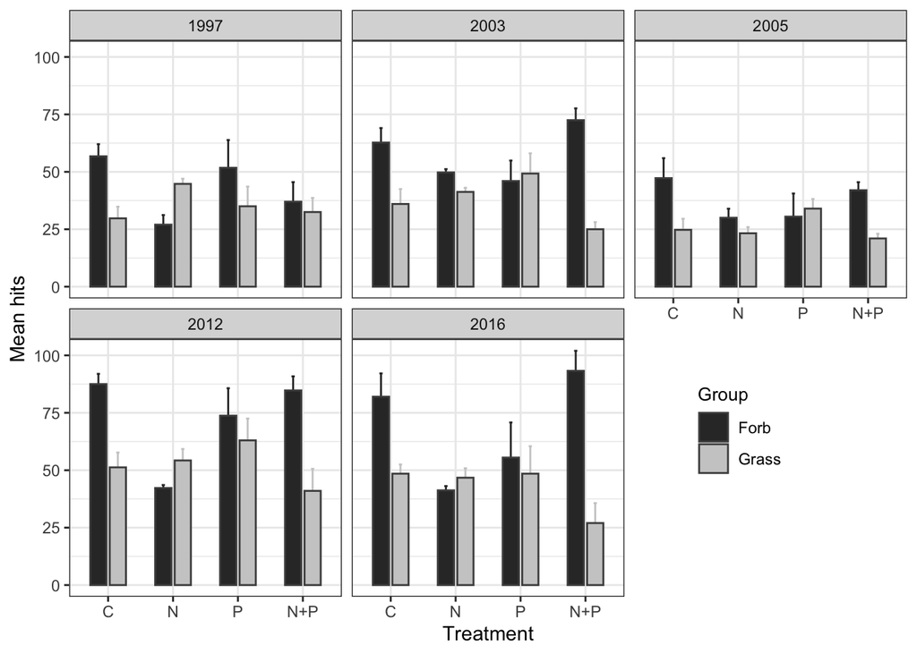

| site | yr | fxngrp_F.stat | fxngrp_p.value | trt_F.stat | trt_p.value | trt:fxngrp_F.stat | trt:fxngrp_p.value |
| --- | --- | --- | --- | --- | --- | --- | --- |
| sdl | 1997 | 2.2922 | 0.1431 | 0.8495 | 0.4805 | 3.6544 | 0.0266 |
| sdl | 2003 | 22.5723 | 0.0001 | 0.1658 | 0.9184 | 7.0217 | 0.0015 |
| sdl | 2005 | 8.5062 | 0.0076 | 0.9246 | 0.4440 | 2.3802 | 0.0947 |
| sdl | 2012 | 13.7691 | 0.0011 | 3.3709 | 0.0350 | 5.7351 | 0.0042 |
| sdl | 2016 | 15.3443 | 0.0006 | 2.0824 | 0.1292 | 6.0423 | 0.0032 |

Mean hits by treatment are significantly different from one another in 2012, otherwise no major differences in what’s significant each year using hits only compared to relativized cover.

#### NutNet Trends

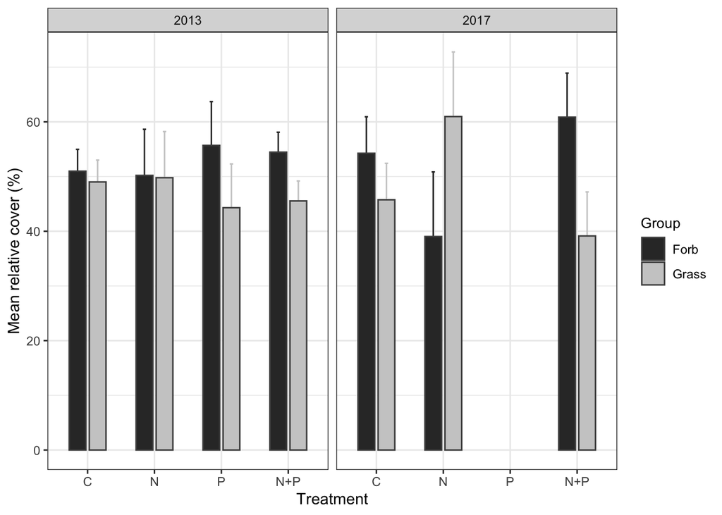

Fig 2. NutNet mean forb and grass relative cover, 2013 and 2017

NutNet mean forb and grass relative cover, by treatment (means, 1 standard error, n = 4 per treatment; 2 reps of C and N+P+K within block averaged before calculating treatment averages across blocks)

| site | yr | fxnlgrp | C mean | C se | N mean | N se | N+P mean | N+P se | P mean | P se |
| --- | --- | --- | --- | --- | --- | --- | --- | --- | --- | --- |
| nutnet | 2013 | Forb | 50.98 | 3.99 | 50.21 | 8.44 | 54.46 | 3.64 | 55.7 | 8 |
| nutnet | 2013 | Grass | 49.02 | 3.99 | 49.79 | 8.44 | 45.54 | 3.64 | 44.3 | 8 |
| nutnet | 2017 | Forb | 54.25 | 6.67 | 39.04 | 11.81 | 60.86 | 8.05 | NA | NA |
| nutnet | 2017 | Grass | 45.75 | 6.67 | 60.96 | 11.81 | 39.14 | 8.05 | NA | NA |

Again, trying everything in a global ANOVA (functional group x treatment x yr), and running two separate ANOVAs for 2013 and 2017. Two replicates for C and N+P+K within block were averaged before running the ANOVA, so that each block only has 1 value of mean grass and 1 value of mean forb per treatment.

```
##             Df Sum Sq Mean Sq F value Pr(>F)
## trt2         2      0     0.0   0.000  1.000
## met          1    128   128.0   0.550  0.463
## yr           1      0     0.0   0.000  1.000
## trt2:met     2   1383   691.4   2.970  0.064 .
## trt2:yr      2      0     0.0   0.000  1.000
## met:yr       1      3     3.0   0.013  0.910
## trt2:met:yr  2    703   351.6   1.510  0.235
## Residuals   36   8381   232.8
## ---
## Signif. codes:  0 '***' 0.001 '**' 0.01 '*' 0.05 '.' 0.1 ' ' 1
```

NutNet grass vs. forb vs. treatment ANOVA, by year

| site | yr | fxngrp_F.stat | fxngrp_p.value | trt2_F.stat | trt2_p.value | trt2:fxngrp_F.stat | trt2:fxngrp_p.value |
| --- | --- | --- | --- | --- | --- | --- | --- |
| nutnet | 2013 | 1.5667 | 0.2227 | 0 | 1 | 0.3430 | 0.7945 |
| nutnet | 2017 | 0.1383 | 0.7143 | 0 | 1 | 3.0199 | 0.0740 |

Dissimilar to Saddle trends, nothing is significant at the NutNet site.

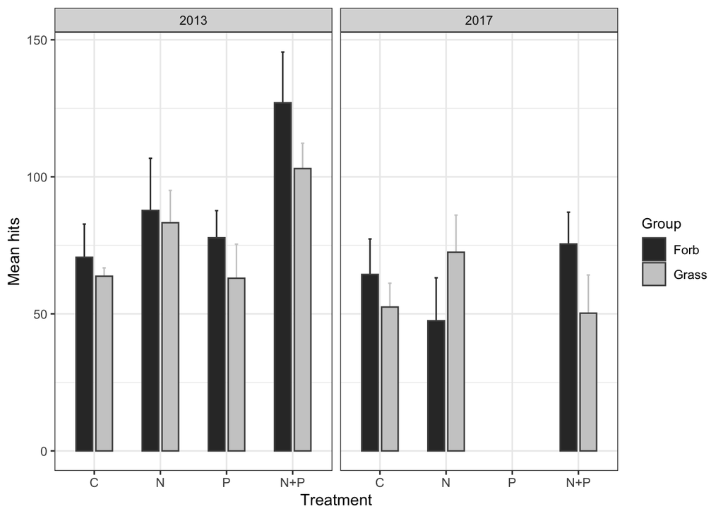

NutNet: ANOVA on mean hits

| site | yr | fxngrp_F.stat | fxngrp_p.value | trt2_F.stat | trt2_p.value | trt2:fxngrp_F.stat | trt2:fxngrp_p.value |
| --- | --- | --- | --- | --- | --- | --- | --- |
| nutnet | 2013 | 1.8772 | 0.1833 | 5.7002 | 0.0043 | 0.2321 | 0.8731 |
| nutnet | 2017 | 0.1471 | 0.7058 | 0.0608 | 0.9412 | 2.0326 | 0.1600 |

NutNet 2013: Significant differences in mean hits (p < 0.05) between functional groups and treatments, tested with Tukey HSD

| comparison | diff | lwr | upr | p.adj | grp | yr |
| --- | --- | --- | --- | --- | --- | --- |
| N+P-C | 47.8125 | 12.1310 | 83.4940 | 0.0058 | trt2 | 2013 |
| N+P-P | 44.6250 | 8.9435 | 80.3065 | 0.0105 | trt2 | 2013 |
| C:GrassHits-N+P:ForbHits | -63.2500 | -123.8325 | -2.6675 | 0.0364 | trt2:met | 2013 |
| P:GrassHits-N+P:ForbHits | -64.0000 | -124.5825 | -3.4175 | 0.0332 | trt2:met | 2013 |

When everything is plotted together, you can see how the shift in *G. rossii* cover at Saddle is driving the shift in forb cover over time. Plotting both sites together also suggests perhaps NutNet is on a similar trajectory to Saddle in shift to forb dominance over time with N+P additions, but not enough years (and N+P additions) have occurred to confirm that trend.

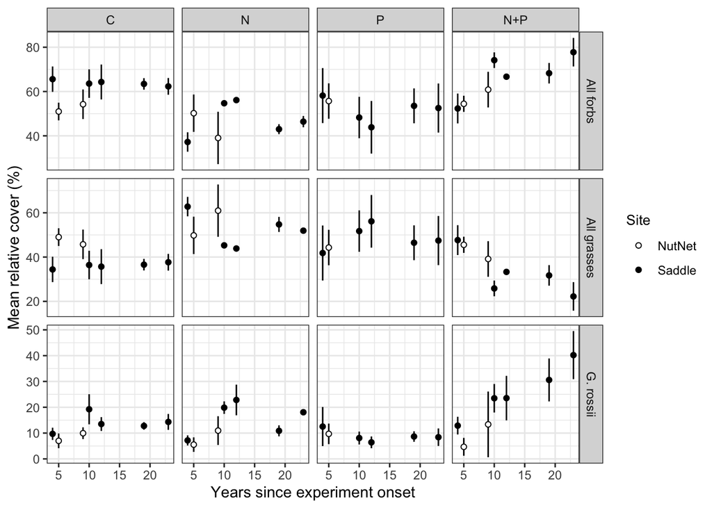

Finally, here are the tables 1-4 recreated using the cleaned datasets:

Table 1. NN 2013 biodiversity, vegetation complexity, and biomass trends per treatment (means, 1 standard error, nutrient and nutrient+micro treatments pooled (8 per group)

| site | yr | variable | nobs | C mean | C se | N mean | N se | P mean | P se | N+P mean | N+P se |
| --- | --- | --- | --- | --- | --- | --- | --- | --- | --- | --- | --- |
| nutnet | 2013 | S | 8 | 22.31 | 1.32 | 25.25 | 1.79 | 23.88 | 1.74 | 27.12 | 1.82 |
| nutnet | 2013 | H | 8 | 2.18 | 0.10 | 2.43 | 0.13 | 2.44 | 0.09 | 2.75 | 0.07 |
| nutnet | 2013 | PlantCov | 8 | 87.25 | 1.24 | 94.75 | 1.00 | 87.88 | 1.32 | 97.94 | 0.49 |
| nutnet | 2013 | Total_g_m2 | 8 | 139.71 | 13.70 | 195.00 | 12.42 | 150.44 | 10.38 | 333.43 | 22.63 |
| nutnet | 2013 | VegHits | 8 | 134.94 | 6.80 | 168.25 | 7.65 | 142.38 | 5.69 | 218.38 | 13.12 |

Table 2. NN 2017 biodiversity, and vegetation complexity (biomass not measured) trends per treatment (means, 1 standard error, n = 4 per treatment [C and N+P+K reps averaged within block (2 rep per block) first]

| site | yr | variable | nobs | C mean | C se | K mean | K se | N mean | N se | N+P mean | N+P se | N+P+K mean | N+P+K se |
| --- | --- | --- | --- | --- | --- | --- | --- | --- | --- | --- | --- | --- | --- |
| nutnet | 2017 | S | 4 | 20.75 | 3.03 | 18.50 | 0.65 | 18.50 | 2.50 | 18.25 | 2.06 | 22.12 | 2.22 |
| nutnet | 2017 | H | 4 | 2.25 | 0.16 | 2.12 | 0.11 | 1.86 | 0.28 | 2.33 | 0.18 | 2.63 | 0.06 |
| nutnet | 2017 | PlantCov | 4 | 71.62 | 9.00 | 75.50 | 5.20 | 88.25 | 2.78 | 87.25 | 5.65 | 86.38 | 3.89 |
| nutnet | 2017 | VegHits | 4 | 116.88 | 13.81 | 96.50 | 11.38 | 120.00 | 10.73 | 125.75 | 14.45 | 142.38 | 16.36 |

Out of curiosity, I repeated this for Saddle for years where data are available:

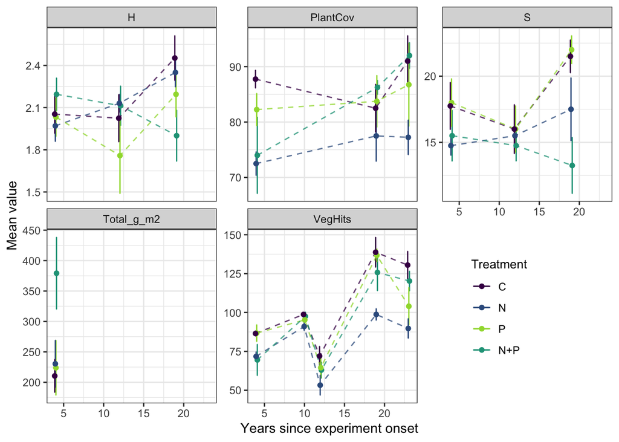

Saddle biodiversity, biomass, and vegetation complexity, for years where data available (means, ± 1 std. error, n = 4 per treatment

Table 3. Mean relative cover of G. rossii at alpine dry meadow plots over time (means, ±1 std error, n = 4 per treatment. S = Saddle, N = NutNet.

| Treatment | n | S 1997 mean | S 1997 se | S 2003 mean | S 2003 se | S 2005 mean | S 2005 se | S 2012 mean | S 2012 se | S 2016 mean | S 2016 se | N 2013 mean | N 2013 se | N 2017 mean | N 2017 se |
| --- | --- | --- | --- | --- | --- | --- | --- | --- | --- | --- | --- | --- | --- | --- | --- |
| C | 4 | 9.70 | 2.37 | 19.23 | 5.83 | 13.50 | 2.68 | 12.77 | 1.46 | 14.32 | 3.08 | 6.99 | 2.85 | 9.95 | 2.28 |
| N | 4 | 7.16 | 1.96 | 19.85 | 2.42 | 22.83 | 5.94 | 10.87 | 2.13 | 18.07 | 0.86 | 5.53 | 2.81 | 10.96 | 5.57 |
| P | 4 | 12.52 | 7.57 | 8.08 | 2.49 | 6.41 | 2.28 | 8.66 | 2.02 | 8.40 | 3.39 | 9.69 | 3.98 | NA | NA |
| N+P | 4 | 12.88 | 3.43 | 23.50 | 5.53 | 23.54 | 8.62 | 30.59 | 8.32 | 40.21 | 9.33 | 4.67 | 3.46 | 13.36 | 12.73 |

Abundant species in NutNet plots by the final year:

Table 4. NutNet 2017, species with mean abundance >= 2% in any treatment, sorted by lifeform and overall mean abundance, n = 4 per treatment group

| site | yr | nobs | clean code2 | species | lifeform | resource grp | C mean | C se | K mean | K se | N mean | N se | N+P mean | N+P se | N+P+K mean | N+P+K se |
| --- | --- | --- | --- | --- | --- | --- | --- | --- | --- | --- | --- | --- | --- | --- | --- | --- |
| nutnet | 2017 | 4 | GERO2 | Geum rossii | Forb | Acquisitive | 9.95 | 2.28 | 7.19 | 4.03 | 10.96 | 5.57 | 13.36 | 12.73 | 7.95 | 3.54 |
| nutnet | 2017 | 4 | CARO2 | Campanula rotundifolia | Forb | Unknown | 5.81 | 1.64 | 6.10 | 1.42 | 1.75 | 0.73 | 9.04 | 2.45 | 10.77 | 1.61 |
| nutnet | 2017 | 4 | SOMU | Solidago multiradiata | Forb | Unknown | 3.00 | 1.35 | 4.92 | 1.98 | 3.53 | 3.03 | 4.35 | 2.53 | 3.20 | 1.54 |
| nutnet | 2017 | 4 | ORALA | Oreoxis alpina | Forb | Conservative | 2.25 | 0.56 | 1.60 | 0.98 | 2.42 | 1.16 | 5.11 | 2.59 | 6.91 | 2.43 |
| nutnet | 2017 | 4 | ARFEF3 | Arenaria fendleri | Forb | Unknown | 3.00 | 1.13 | 0.35 | 0.35 | 3.06 | 1.13 | 5.53 | 2.37 | 4.56 | 0.94 |
| nutnet | 2017 | 4 | ALGE | Allium geyeri | Forb | Unknown | 3.51 | 1.30 | 2.07 | 0.35 | 0.39 | 0.23 | 4.67 | 1.34 | 4.74 | 1.66 |
| nutnet | 2017 | 4 | MIOB2 | Minuartia obtusiloba | Forb | Conservative | 4.09 | 0.52 | 2.52 | 1.53 | 1.07 | 0.70 | 1.26 | 0.91 | 2.30 | 0.87 |
| nutnet | 2017 | 4 | POBI6 | Polygonum bistortoides | Forb | Acquisitive | 1.50 | 0.24 | 0.80 | 0.29 | 1.48 | 0.94 | 3.43 | 0.79 | 2.96 | 1.19 |
| nutnet | 2017 | 4 | SEDES | Selaginella densa | Forb | Unknown | 4.69 | 1.00 | 2.45 | 1.10 | 0.46 | 0.27 | 0.55 | 0.18 | 0.09 | 0.09 |
| nutnet | 2017 | 4 | LLSE | Lloydia serotina | Forb | Conservative | 2.69 | 1.10 | 2.47 | 2.10 | 1.72 | 1.16 | 0.67 | 0.40 | 0.57 | 0.44 |
| nutnet | 2017 | 4 | SELA | Sedum lanceolatum | Forb | Unknown | 1.46 | 0.76 | 1.80 | 0.79 | 1.11 | 0.47 | 0.86 | 0.86 | 2.50 | 0.31 |
| nutnet | 2017 | 4 | ARSC | Artemisia scopulorum | Forb | Acquisitive | 0.61 | 0.35 | 2.13 | 1.70 | 1.49 | 1.49 | 0.00 | 0.00 | 2.85 | 2.06 |
| nutnet | 2017 | 4 | MELA3 | Mertensia lanceolata | Forb | Unknown | 0.91 | 0.61 | 0.20 | 0.20 | 0.00 | 0.00 | 3.24 | 1.09 | 1.32 | 0.92 |
| nutnet | 2017 | 4 | POVI | Polemonium viscosum | Forb | Unknown | 0.00 | 0.00 | 0.00 | 0.00 | 0.00 | 0.00 | 0.00 | 0.00 | 5.28 | 2.84 |
| nutnet | 2017 | 4 | CEARS2 | Cerastium arvense | Forb | Unknown | 0.47 | 0.35 | 0.00 | 0.00 | 0.23 | 0.23 | 2.12 | 1.23 | 2.17 | 0.55 |
| nutnet | 2017 | 4 | CAUN2 | Campanula uniflora | Forb | Unknown | 0.23 | 0.13 | 0.28 | 0.28 | 2.51 | 1.00 | 0.29 | 0.29 | 0.10 | 0.10 |
| nutnet | 2017 | 4 | KOMY | Kobresia myosuroides | Grass | Conservative | 29.02 | 7.10 | 30.68 | 6.12 | 19.73 | 9.81 | 15.90 | 4.52 | 7.86 | 2.50 |
| nutnet | 2017 | 4 | CARUD | Carex rupestris | Grass | Conservative | 14.82 | 0.61 | 21.48 | 6.76 | 36.91 | 4.95 | 4.05 | 2.93 | 11.43 | 2.50 |
| nutnet | 2017 | 4 | TRSP2 | Trisetum spicatum | Grass | Unknown | 0.24 | 0.24 | 0.28 | 0.28 | 0.23 | 0.23 | 10.53 | 3.77 | 6.85 | 2.22 |
| nutnet | 2017 | 4 | POA | Poa sp. | Grass | Unknown | 0.32 | 0.32 | 0.79 | 0.79 | 0.38 | 0.22 | 4.89 | 3.17 | 4.42 | 1.38 |
| nutnet | 2017 | 4 | CAPU | Calamagrostis purpurascens | Grass | Unknown | 0.00 | 0.00 | 2.00 | 2.00 | 3.23 | 2.91 | 1.59 | 1.59 | 0.00 | 0.00 |

#### Multivariate analyses

Considering the same plots analyzed above for forb and grass relative cover, what can we learn from multivariate analyses about shifts in forb and grass species abundances by treatment overtime at each site?

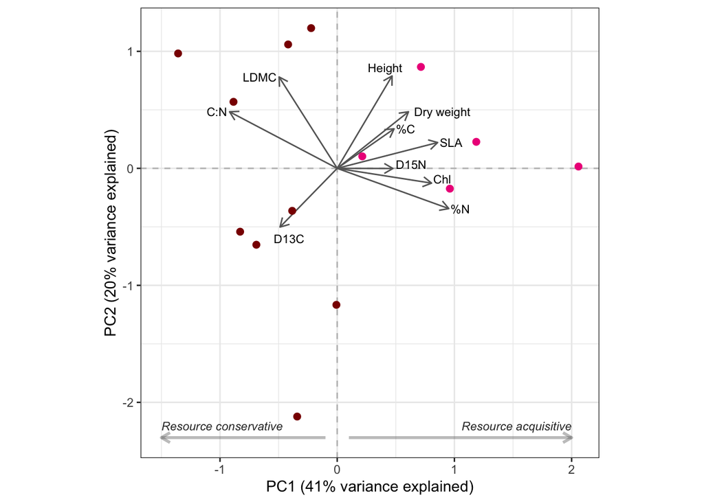

Fig 3. PCA of functional traits for available Saddle dry meadow species in Spasojevic and Weber (2018)

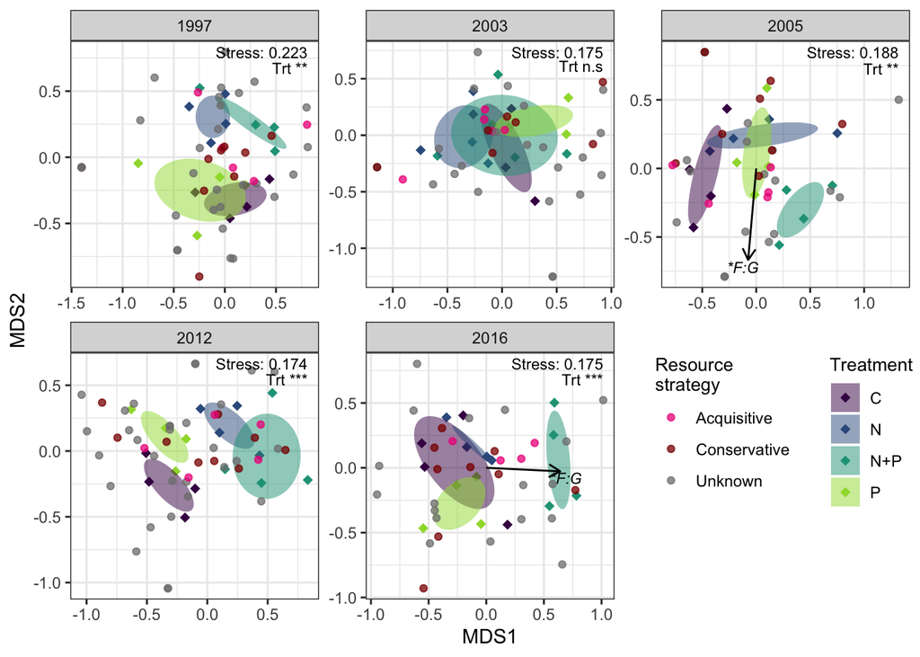

Fig 4. Saddle dry meadow NMDS, arrayed by year. Species (circle points) colored by PCA resource group. Sites (diamond points), with 95% confidence ellipses shaded, colored by nutrient treatment (n = 4 sites per treatment).

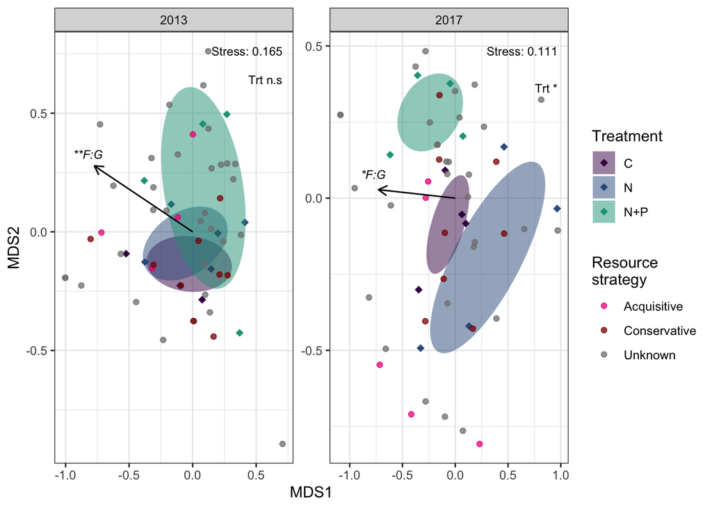

Fig 5. NutNet dry meadow NMDS, arrayed by year. Species (circle points) colored by PCA resource group. Sites (diamond points), with 95% confidence ellipses shaded, colored by nutrient treatment (n = 4 sites per treatment).

### Supplemental multivariate analyses

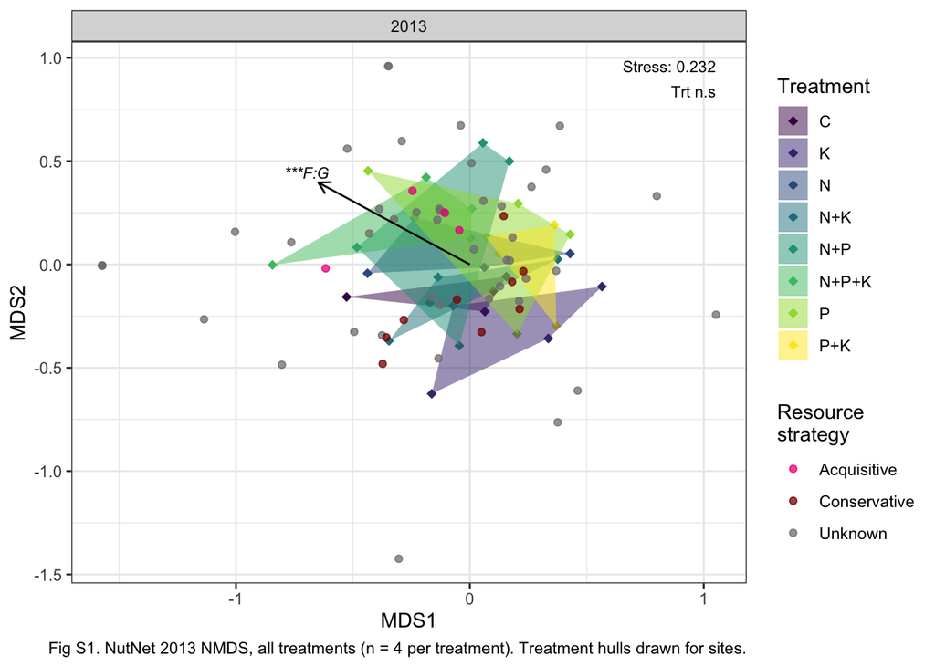

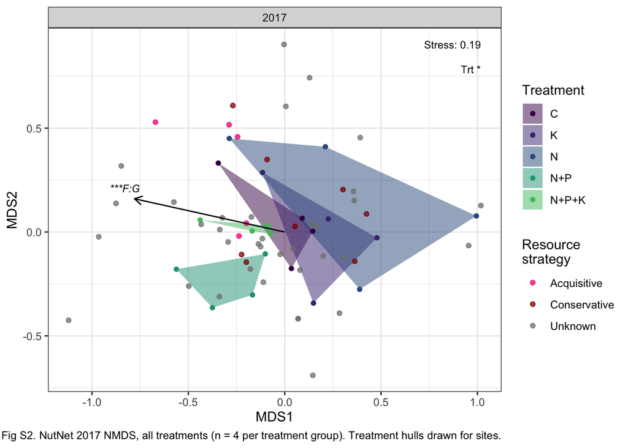

Table S1. Permutation statistics (permanova and permdisp) for alpine dry meadow communities, iterations = 1000

| tracker | site | yr | fig | trt | lnF2G F.Stat | lnF2G R2 | trt F.Stat | trt R2 | trt:lnF2G F.Stat | trt:lnF2G R2 | dispersion F.stat |
| --- | --- | --- | --- | --- | --- | --- | --- | --- | --- | --- | --- |
| main_1997 | sdl | 1997 | main | C, N, N+P, P | 5.389 *** | 0.201 | 3.612 *** | 0.403 | 0.882 n.s | 0.098 | 2.687 . |
| main_2003 | sdl | 2003 | main | C, N, N+P, P | 1.671 n.s | 0.093 | 2.246 ** | 0.375 | 0.525 n.s | 0.088 | 0.471 n.s |
| main_2005 | sdl | 2005 | main | C, N, N+P, P | 2.798 * | 0.113 | 3.593 ** | 0.434 | 1.082 n.s | 0.131 | 0.686 n.s |
| main_2012 | sdl | 2012 | main | C, N, N+P, P | 1.761 n.s | 0.063 | 4.66 *** | 0.5 | 1.398 n.s | 0.15 | 0.376 n.s |
| main_2016 | sdl | 2016 | main | C, N, N+P, P | 2.268 . | 0.079 | 4.66 *** | 0.49 | 1.43 n.s | 0.15 | 1.232 n.s |
| main_2013 | nutnet | 2013 | main | C, N, N+P | 3.242 ** | 0.217 | 2.108 * | 0.283 | 0.73 n.s | 0.098 | 1.327 n.s |
| main_2017 | nutnet | 2017 | main | C, N, N+P | 4.843 *** | 0.236 | 4.224 *** | 0.411 | 0.626 n.s | 0.061 | 2.8 n.s |
| suppl_2013 | nutnet | 2013 | suppl | C, K, N, N+K, N+P, N+P+K, P, P+K | 6.432 *** | 0.138 | 2.287 *** | 0.343 | 1.18 n.s | 0.177 | 0.927 n.s |
| suppl_2017 | nutnet | 2017 | suppl | C, K, N, N+P, N+P+K | 4.939 *** | 0.17 | 2.947 *** | 0.405 | 0.593 n.s | 0.082 | 1.507 n.s |

Marko and Soren’s trait dataset overlaps much more with the NutNet/Saddle snowfence fert experiment species list if we allow trait data collected outside Saddle dry meadow sites. Here is the PCA and select NMDS figures remade with alternate resource grouping, along with a table of species and their resource grouping designation derived from dry-meadow only PCA vs. all sites PCA. Whether I select dry meadow only or use trait data from more sites, the resource grouping designation is the same except for 3 species: *Deschampsia cespitosa*, *Tetraneuris grandiflora*, and *Trifolium dasyphyllum*.

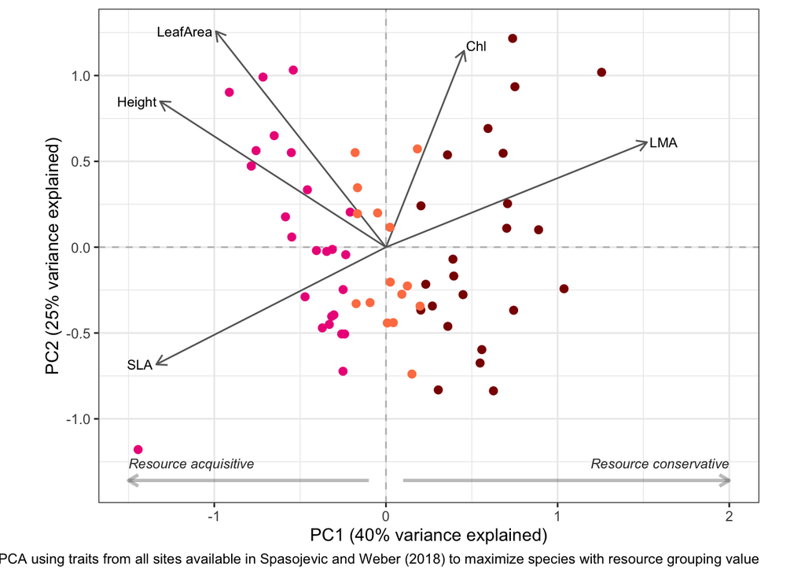

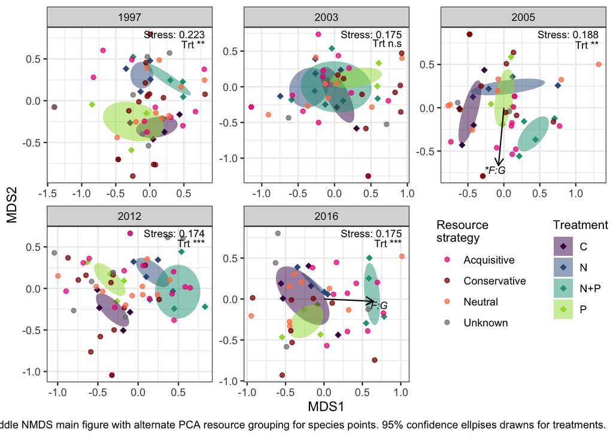

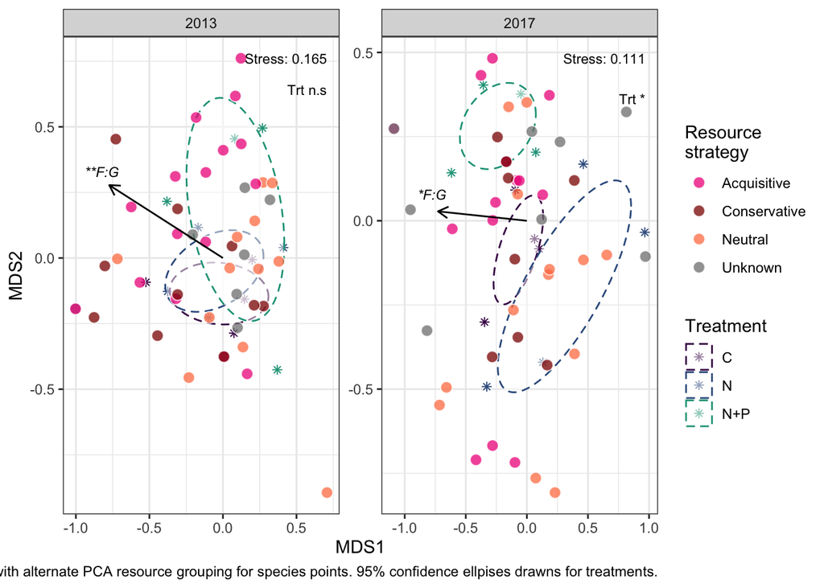

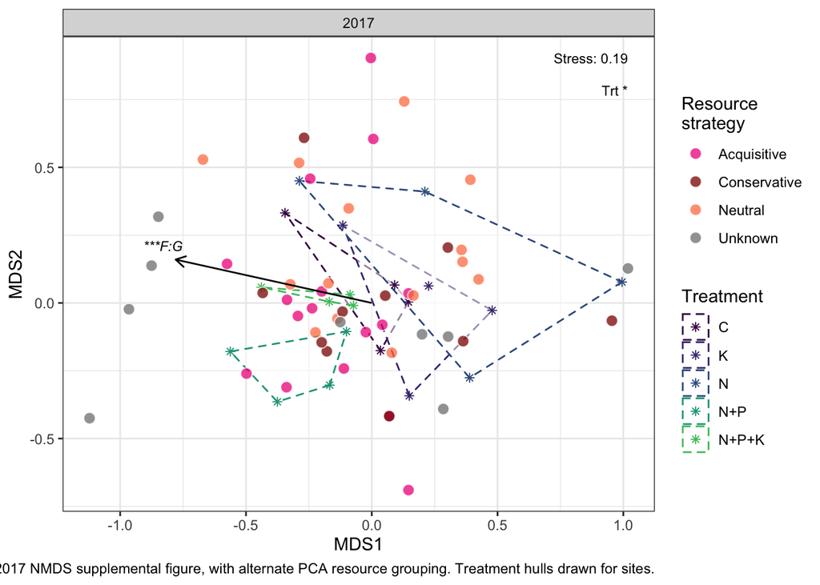

Species resource grouping designations based on PCA (dry meadow-only traits vs all sites traits)

| clean_code2 | simple_name | simple_lifeform2 | DM-only group | All sites grp1 | All sites grp2 |
| --- | --- | --- | --- | --- | --- |
| ACMIA | Achillea millefolium | Forb | Unknown | Acquisitive | Acquisitive |
| ARSC | Artemisia scopulorum | Forb | Acquisitive | Acquisitive | Acquisitive |
| CARO2 | Campanula rotundifolia | Forb | Unknown | Acquisitive | Acquisitive |
| CAHEE | Carex heteroneura | Grass | Unknown | Acquisitive | Acquisitive |
| CANO3 | Carex nova | Grass | Unknown | Acquisitive | Acquisitive |
| CASC12 | Carex scopulorum | Grass | Unknown | Acquisitive | Acquisitive |
| CAOC4 | Castilleja occidentalis | Forb | Unknown | Acquisitive | Acquisitive |
| CEARS2 | Cerastium arvense | Forb | Unknown | Acquisitive | Acquisitive |
| DECE | Deschampsia cespitosa | Grass | Conservative | Acquisitive | Acquisitive |
| ERME2 | Erigeron melanocephalus | Forb | Unknown | Acquisitive | Acquisitive |
| ERSI3 | Erigeron simplex | Forb | Unknown | Acquisitive | Acquisitive |
| GERO2 | Geum rossii | Forb | Acquisitive | Acquisitive | Acquisitive |
| LUSP4 | Luzula spicata | Grass | Unknown | Acquisitive | Acquisitive |
| MELA3 | Mertensia lanceolata | Forb | Unknown | Acquisitive | Acquisitive |
| PEPA3 | Pedicularis parryi | Forb | Unknown | Acquisitive | Acquisitive |
| POAL2 | Poa alpina | Grass | Unknown | Acquisitive | Acquisitive |
| POPU3 | Polemonium pulcherrimum | Forb | Unknown | Acquisitive | Acquisitive |
| POBI6 | Polygonum bistortoides | Forb | Acquisitive | Acquisitive | Acquisitive |
| PODI2 | Potentilla diversifolia | Forb | Unknown | Acquisitive | Acquisitive |
| TRPAP | Trifolium parryi | Forb | Unknown | Acquisitive | Acquisitive |
| TRSP2 | Trisetum spicatum | Grass | Unknown | Acquisitive | Acquisitive |
| ALGE | Allium geyeri | Forb | Unknown | Conservative | Conservative |
| DRAU | Draba aurea | Forb | Unknown | Conservative | Conservative |
| DRST4 | Draba streptocarpa | Forb | Unknown | Conservative | Conservative |
| ERPI6 | Erigeron pinnatisectus | Forb | Unknown | Conservative | Conservative |
| ERNA | Eritrichium nanum | Forb | Unknown | Conservative | Conservative |
| ERCA14 | Erysimum capitatum | Forb | Unknown | Conservative | Conservative |
| KOMY | Kobresia myosuroides | Grass | Conservative | Conservative | Conservative |
| MIOB2 | Minuartia obtusiloba | Forb | Conservative | Conservative | Conservative |
| NOFEG | Noccaea fendleri | Forb | Unknown | Conservative | Conservative |
| ORALA | Oreoxis alpina | Forb | Conservative | Conservative | Conservative |
| PACA15 | Packera cana | Forb | Unknown | Conservative | Conservative |
| PAPU2 | Paronychia pulvinata | Forb | Unknown | Conservative | Conservative |
| PHPU5 | Phlox pulvinata | Forb | Unknown | Conservative | Conservative |
| POGL | Poa glauca | Grass | Unknown | Conservative | Conservative |
| POVI | Polemonium viscosum | Forb | Unknown | Conservative | Conservative |
| PRAN | Primula angustifolia | Forb | Unknown | Conservative | Conservative |
| SIACS2 | Silene acaulis | Forb | Conservative | Conservative | Conservative |
| TEACC | Tetraneuris acaulis | Forb | Conservative | Conservative | Conservative |
| TOPY | Tonestus pygmaeus | Forb | Unknown | Conservative | Conservative |
| VIAD | Viola adunca | Forb | Unknown | Conservative | Conservative |
| ANAL4 | Antennaria alpina | Forb | Unknown | Conservative | Neutral |
| ARFEF3 | Arenaria fendleri | Forb | Unknown | Acquisitive | Neutral |
| CAPU | Calamagrostis purpurascens | Grass | Unknown | Acquisitive | Neutral |
| CARUD | Carex rupestris | Grass | Conservative | Conservative | Neutral |
| CHJA | Chionophila jamesii | Forb | Unknown | Acquisitive | Neutral |
| DAIN | Danthonia intermedia | Grass | Unknown | Conservative | Neutral |
| FEBR | Festuca brachyphylla | Grass | Conservative | Conservative | Neutral |
| LEPY2 | Lewisia pygmaea | Forb | Unknown | Conservative | Neutral |
| LLSE | Lloydia serotina | Forb | Conservative | Conservative | Neutral |
| POVI3 | Polygonum viviparum | Forb | Unknown | Acquisitive | Neutral |
| SARH2 | Saxifraga rhomboidea | Forb | Unknown | Acquisitive | Neutral |
| SELA | Sedum lanceolatum | Forb | Unknown | Conservative | Neutral |
| SIPR | Sibbaldia procumbens | Forb | Unknown | Acquisitive | Neutral |
| TEGR3 | Tetraneuris grandiflora | Forb | Acquisitive | Conservative | Neutral |
| TRDA2 | Trifolium dasyphyllum | Forb | Acquisitive | Conservative | Neutral |